# Lab 6 (week 7) - What mediates coexistence?

Mads

# Announcements

[output not shown]

2. We want to know how working in your groups has been!

# Competitiion

In this lab, we will be continuing our study of competition between species.

We will be using **explicit** models of competition. In this case, we will specifically be using models in which two competitors (N and M) share a resource (R). Thus, each species has a negative effect on the other by depleting the resource that the competitor also needs for survival.

This system will follow the set of ordinary differential equations:

$$\begin{align}
\frac{d R}{dt} &= r R (1-\frac{R}{K}) - a_N R N - a_M R M \\
\newline
\frac{d N}{dt} &= e a_N R N - l_N N \\
\newline
\frac{d M}{dt} &= e a_M R M - l_M M \\
\end{align}$$
First, we’ll demonstrate that the dominant competitor in this system is the one that can draw resources down to the lowest level.

Second, we’ll explore two mechanisms by which species can coexist in this system:  
One mechanism will be “bottom-up” – niche partitioning via specialization on two different resources.  
The second mechanism will be “top-down” – predator-mediated coexistence.

# 1. Competitive exclusion

## a. Parameterizing the model

First, let’s set up the resource’s parameters.

```r
r <- .5     # growth rate of resource R
K <- 100    # carrying capacit yof resource R
```

Second, let’s set up the biological parameters for competitor N.

```r
a_N <- 0.2  # attack rate of our nurse sharks
e <- 0.05     # conversion efficiency
l_N <- 0.01 # death rate of nurse sharks
```

Third, let’s set up competitor M to be the same as competitor N, except for having a 50% higher affinity/attack rate.

```r
a_M <- a_N*1.5  # attack rate of morays is bigger than that of nurse sharks
l_M <- l_N      # but death rate is the same
```

## b. Calculating Tilman’s R* for each species

By setting $\frac{dN}{dt} = 0$ and $\frac{dM}{dt} = 0$, we can calculate R* for each species.

**Note:** Even though we generally use “star” or an asterisk * to denote equilibria, in this case $R^*$ is Tilman’s $R^*$, which is the **lowest possible resource level at which a species can persist.**

$$\begin{align}
\frac{d N}{dt} = 0 &= e a_N R N - l_N N \\
l_N N &= e a_N R N \\
l_N &= e a_N R \\
R^* &= \frac{l_N}{e a_N}
\end{align}$$

```r
#as a goes up Rstar goes down. we hypothesize that moray will have smaller Rstar than nurse shark bc its attack rate is larger
Rstar_N <- l_N/e/a_N
Rstar_N
```

```
## [1] 1
```

```r
Rstar_M <- l_M/e/a_M
Rstar_M
```

```
## [1] 0.6666667
```

Species M has a lower $R^*$ than species N. If this is the case, which species is the **competitive dominiant**? Write your prediction below: M

## c. Checking our prediction with a simulation

**Note:** In each simulation, we’re going to slightly alter the `length.out` or `to` arguments in the `seq()` function when creating our timestep vectors (starting with `tset`). Pay attention to these differences! This is to ensure that when we plot, we’re plotting the right simulations. For the timesteps in our first simulation, we’ll use:

```r
# create a vector of timesteps
tset1 <- seq(from = 0, to = 10000, length.out = 100000)
```

Now we’re ready to build the rest of our loop.

```r
# create holding vectors and fill initial conditions
R.simu1 <- NaN*tset1; R.simu1[1] <- 0.5
N.simu1 <- NaN*tset1; N.simu1[1] <- 1
M.simu1 <- NaN*tset1; M.simu1[1] <- 1

# for each timestep
for(i in 2:length(tset1)){
  # calculate change in time
    dt <- tset1[i]-tset1[i-1]

    # store placeholder variables
    R <- R.simu1[i-1]
    N <- N.simu1[i-1]
    M <- M.simu1[i-1]

    # calculate change in resource level and population size
    dR <- ( r*R*(1-R/K) - a_N*N*R - a_M*M*R )*dt
    dN <- ( e*a_N*N*R - l_N*N )*dt
    dM <- ( e*a_M*M*R - l_M*M )*dt

    # calculate total resource level and population size
    R.simu1[i] <- R + dR
    N.simu1[i] <- N + dN
    M.simu1[i] <- M + dM
}
```

Check to make sure your loop worked!

```r
head(N.simu1)
```

```
## [1] 1.0000000 0.9995000 0.9990001 0.9985004 0.9980008 0.9975013
```

```r
tail(N.simu1)
```

```
## [1] 4.654326e-15 4.652774e-15 4.651224e-15 4.649673e-15 4.648123e-15
## [6] 4.646574e-15
```

Examine your results with plots. Because the y-axis scales may be different, we’ll use separate plots for the resource, and the two competitors.

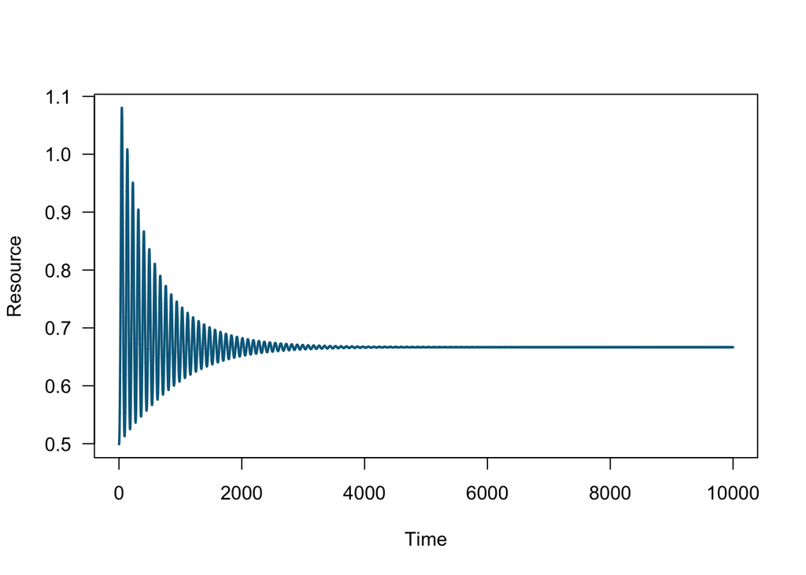

```r
# store colors for R, N, and M - feel free to use your own!
Rcol <- 'deepskyblue4'
Ncol <- 'coral'
Mcol <- 'seagreen'

# plot resource as a function of time
plot(x = tset1, y = R.simu1,
     type = 'l', las = 1, lwd = 2, col = Rcol,
     xlab = 'Time', ylab = 'Resource')
```

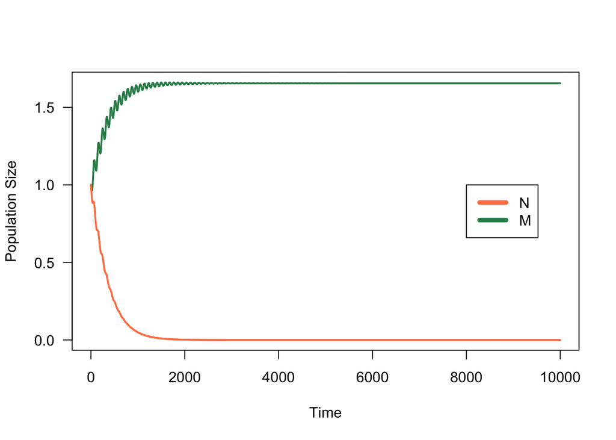

```r
# plot population size of M and N as a function of time
plot(x = tset1, y = M.simu1,
     type = 'l', las = 1, lwd = 2, col = Mcol,
     xlab = 'Time', ylab = 'Population Size',
     ylim = c(0, max(c(max(M.simu1,N.simu1)))))
lines(x = tset1, y = N.simu1,
      lwd = 2, col = Ncol)
legend(x = 8000, y = 1, legend = c('N', 'M'), lwd = 5, col = c(Ncol, Mcol))
```

Check to see if your prediction was correct. The ‘tail’ function can also help you check whether you’ve reached equilibrium.

```r
# check if rabbitfish are at equilibrium
tail(R.simu1)
```

```
## [1] 0.6666665 0.6666665 0.6666665 0.6666665 0.6666665 0.6666665
```

```r
# lets remember our Rstar for morays
Rstar_M
```

```
## [1] 0.6666667
```

### Think, Pair, Share 1

Alter the parameters such that N and M differ ONLY in mortality rates (`a_N` = `a_M`, but `l_N` is different from `l_M`).

```r
a_N1 <- 0.2 # attack rate of our nurse sharks
e1 <- 0.05    # conversion efficiency
l_N1 <- 0.01    # death rate of nurse sharks

a_M1 <- a_N1 # attack rate of morays is bigger than that of nurse sharks
l_M1 <- l_N1*1.5      # but death rate is the same


# create holding vectors and fill initial conditions
R.simu2 <- NaN*tset1; R.simu2[1] <- 0.5
N.simu2 <- NaN*tset1; N.simu2[1] <- 1
M.simu2 <- NaN*tset1; M.simu2[1] <- 1

# for each timestep
for(i in 2:length(tset1)){
  # calculate change in time
    dt <- tset1[i]-tset1[i-1]

    # store placeholder variables
    R <- R.simu2[i-1]
    N <- N.simu2[i-1]
    M <- M.simu2[i-1]

    # calculate change in resource level and population size
    dR <- ( r*R*(1-R/K) - a_N1*N*R - a_M1*M*R )*dt
    dN <- ( e1*a_N1*N*R - l_N1*N )*dt
    dM <- ( e1*a_M1*M*R - l_M1*M )*dt

    # calculate total resource level and population size
    R.simu2[i] <- R + dR
    N.simu2[i] <- N + dN
    M.simu2[i] <- M + dM
}

head(N.simu2)
```

```
## [1] 1.0000000 0.9995000 0.9990051 0.9985154 0.9980309 0.9975517
```

```r
tail(N.simu2)
```

```
## [1] 2.475 2.475 2.475 2.475 2.475 2.475
```

1. Based on your parameter choices, which species do you expect to win?
2. Calculate $R^*$ for each species

```r
# R* for species N
Rstar_N <- l_N1/e1/a_N1
Rstar_N
```

```
## [1] 1
```

```r
# R* for species M
Rstar_M <- l_M1/e1/a_M1
Rstar_M
```

```
## [1] 1.5
```

3. Check your prediction with a simulation and plot the result. Use `tset1` for your timesteps, and remember this is your **second** simulation (so your `.simu` number should be…)

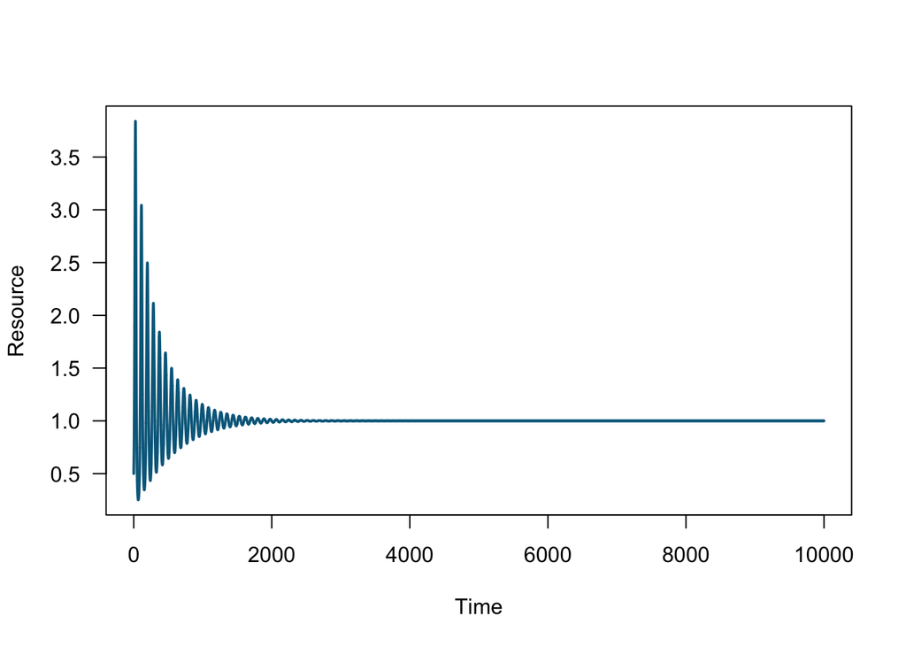

```r
# plot resource as a function of time
plot(x = tset1, y = R.simu2,
     type = 'l', las = 1, lwd = 2, col = Rcol,
     xlab = 'Time', ylab = 'Resource')
```

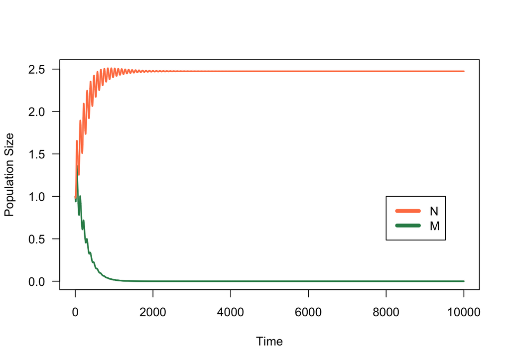

```r
# plot population size of M and N as a function of time
plot(x = tset1, y = M.simu2,
     type = 'l', las = 1, lwd = 2, col = Mcol,
     xlab = 'Time', ylab = 'Population Size',
     ylim = c(0, max(c(max(M.simu2,N.simu2)))))
lines(x = tset1, y = N.simu2,
      lwd = 2, col = Ncol)
legend(x = 8000, y = 1, legend = c('N', 'M'), lwd = 5, col = c(Ncol, Mcol))
```

# 2. Coexistence via niche partitioning

One way that ecologists think species may coexist is by utilizing different resources. In an extreme case, two species could specialize and not compete at all (e.g., if Species N uses only resource R, and Species M uses only resource S). However, even when both species use both resources, coexistence is possible if each species prefers (and therefore is limited by) a different resource.

This is conceptually a parallel idea to the Lotka-Volterra conclusion that coexistence occurs when intraspecific competition is stronger than interspecific competition. In this case, in which we explicitly account for resources, each species is limited by a different resource, and so intraspecific competition (with conspecifics, for the limiting resource) is stronger than interspecific competition (with the other species, for the non-limiting resource).

## a. Developing a two-resource model for a single consumer

When a species requires more than one resource to grow, we have to think carefully about how to formulate its growth rate. In this case, let’s imagine that the two resources are “interchangeable” – that is, the the competitors could survive on either one or the other (e.g., two prey items for a predator, as opposed to two “essential” resources like food and water).

Let’s imagine that species $N$ can use two resources, $R$ and $S$, to grow. It takes up $R$ at a rate $a_N$, and takes up $S$ at a rate $b_N$. We can write:

$$\begin{align}
\frac{d R}{dt} &= r R (1-\frac{R}{K}) - a_N R N \\
\newline
\frac{d S}{dt} &= r S (1-\frac{S}{K}) - b_N S N \\
\newline
\frac{d N}{dt} &= e N (a_N R + b_N S) - l_N N\\
\end{align}$$

## b. Parameterizing, predicting, and simulating

We’re using the same parameters for the resource, but we’ll store these again just in case.

```r
r <- .5     # Intrinsic growth rate of the resources
K <- 100    # Carrying capacity of the resources
```

Then we’ll specify $N$’s biological parameters, assuming $N$ prefers resource $S$.

```r
#rabbitfish = 'a'
#shrimp = 'b'
a_N <- 0.01 # Affinity or attack rate of N for/on the resource R
b_N <- 0.2  # Affinity or attack rate of N for/on the resource S
e <- 0.05   # Conversion efficiency of resources into N
l_N <- 0.01 # Mortality rate of N
```

We can now calculate an $R^*$ and an $S^*$.

```r
Rstar_N <- l_N/e/a_N #death rate over (conversion effic *attack on rabbitfish)
Sstar_N <- l_N/e/b_N #death rate over (conversion effic *attack on shrimp)
Rstar_N
```

```
## [1] 20
```

```r
Sstar_N
```

```
## [1] 1
```

What do you predict the equilibrium values of R and S will be? Write them below:

And, now we can simulate:

```r
# create tset3: notice that this is different from tset1!
tset3 <- seq(from = 0, to = 10000, length.out = 100005)

# create holding vectors and fill initial conditions
R.simu3 <- NaN*tset3; R.simu3[1] <- 40
S.simu3 <- NaN*tset3; S.simu3[1] <- 40
N.simu3 <- NaN*tset3; N.simu3[1] <- 1

# for each timestep
for(i in 2:length(tset3)){
  # calculate change in time
    dt <- tset3[i]-tset3[i-1]

    # store placeholder variables
    R <- R.simu3[i-1]
    S <- S.simu3[i-1]
    N <- N.simu3[i-1]

    # calculate change in resources R and S and population size of N
    dR <- ( r*R*(1-R/K) - a_N*R*N )*dt
    dS <- ( r*S*(1-S/K) - b_N*S*N )*dt
    dN <- ( e*N*(a_N*R+b_N*S) - l_N*N )*dt

    # calculate total resource level of R and S and population size of N
    R.simu3[i] <- R + dR
    S.simu3[i] <- S + dS
    N.simu3[i] <- N + dN
}
```

We’ll check the output of our `for()` loop:

```r
head(N.simu3)
```

```
## [1] 1.000000 1.040998 1.084154 1.129556 1.177291 1.227444
```

```r
tail(N.simu3)
```

```
## [1] 40 40 40 40 40 40
```

And now we can plot!

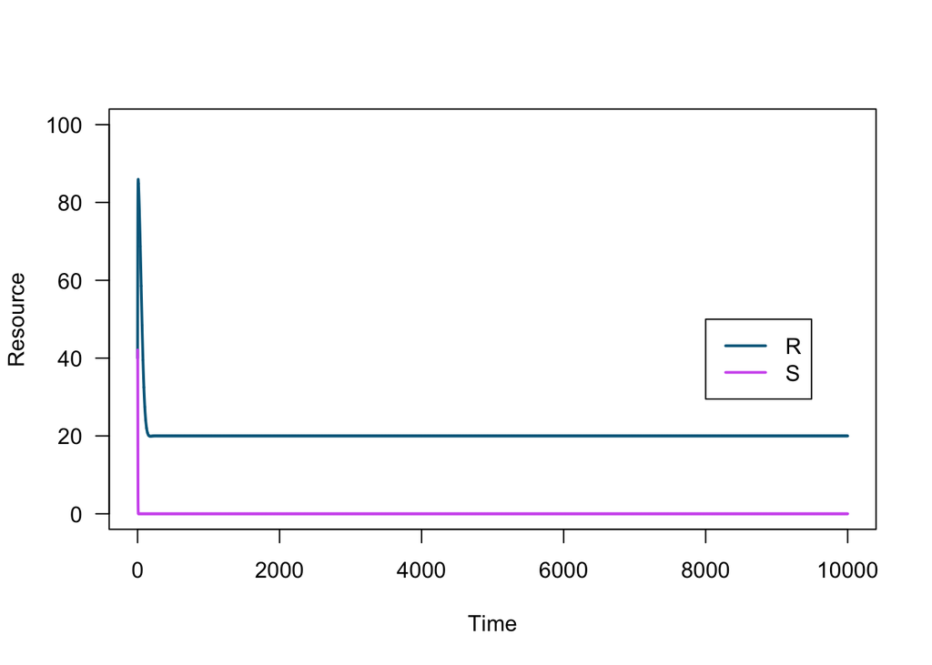

```r
# store colors for R, S, and N
Rcol <- 'deepskyblue4'
Scol <- 'mediumorchid2'
Ncol <- 'coral'

# plot resources R and S as a function of time
plot(x = tset3, y = R.simu3,
     type = 'l', las = 1, lwd = 2, col = Rcol,
     xlab = 'Time', ylab = 'Resource',
     ylim = c(0, K))
lines(x = tset3, y = S.simu3,
      lwd = 2, col = Scol)
legend(x = 8000, y = K/2,
       legend = c('R', 'S'),
       lwd = 2, col = c(Rcol, Scol))
```

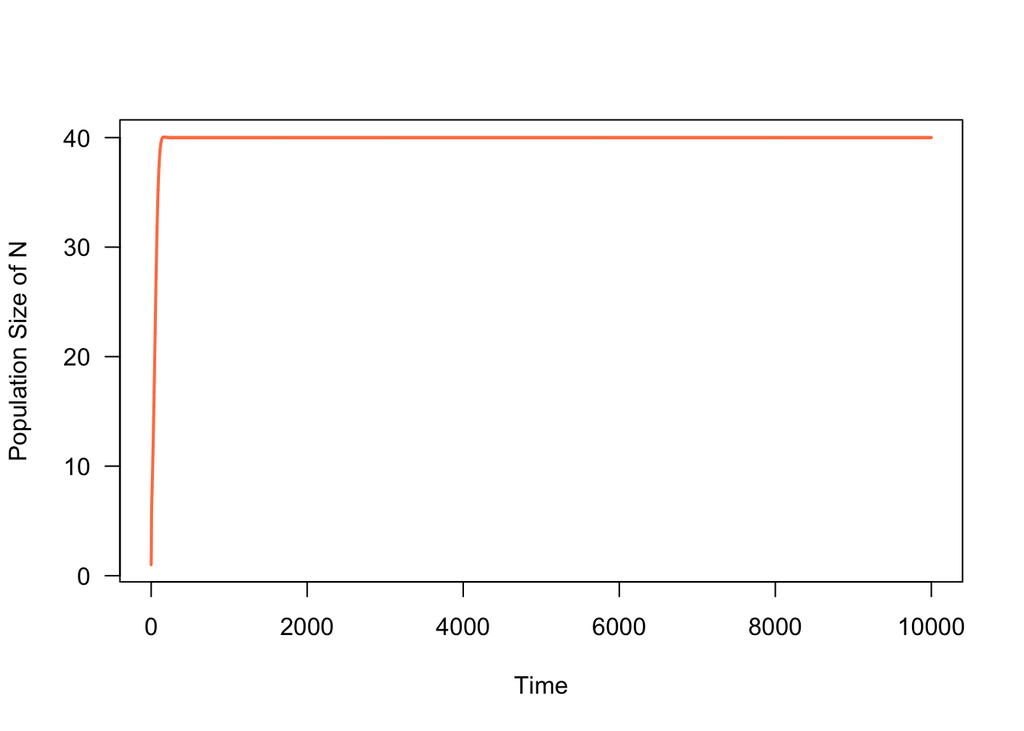

```r
# plot N as a function of time
plot(x = tset3, y = N.simu3,
     type = 'l', las = 1, lwd = 2, col = Ncol,
     xlab = 'Time', ylab = 'Population Size of N')
```

Check to see which resource was limiting (and that you’re at an equilibrium).

```r
# equilibrium of R
tail(R.simu3)
```

```
## [1] 20 20 20 20 20 20
```

```r
# R* of species N
Rstar_N
```

```
## [1] 20
```

```r
# equilibrium of S
tail(S.simu3)
```

```
## [1] 9.881313e-324 9.881313e-324 9.881313e-324 9.881313e-324 9.881313e-324
## [6] 9.881313e-324
```

```r
# S* of species N
Sstar_N
```

```
## [1] 1
```

## c. Introducing competitor M

As before, let’s imagine that $M$ has the greater affinity for resource $R$.

```r
a_M <- a_N*50 #attack of moray on rabbitfish
l_M <- l_N# same death rate
```

In order for coexistence to be possible, do you predict that $M$ must have a *higher* or *lower* affinity for the second resource, $S$? Write your prediction below:

Let’s set $b_M = b_N*0.02$ so that $M$ has a lower affinity for resource $S$ than resource $R$.

```r
b_M <- b_N*0.02 # morats arent good at catching shrimp
```

Let’s check affinity parameters among our competitors.

```r
a_N # affinity of species N for resource R
```

```
## [1] 0.01
```

```r
a_M # affinity of species M for resource R
```

```
## [1] 0.5
```

```r
b_N # affinity of species N for resource S
```

```
## [1] 0.2
```

```r
b_M # affinity of species M for resource S
```

```
## [1] 0.004
```

## d. Calculate R* and S* for each species.

```r
Rstar_N <- l_N/e/a_N
Rstar_M <- l_M/e/a_M
Rstar_N
```

```
## [1] 20
```

```r
Rstar_M
```

```
## [1] 0.4
```

```r
Sstar_N <- l_N/e/b_N
Sstar_M <- l_M/e/b_M
Sstar_N
```

```
## [1] 1
```

```r
Sstar_M
```

```
## [1] 50
```

## e. Checking for coexistence using simulation

```r
# create timesteps - notice the length.out argument!
tset5 <- seq(from = 0, to = 10000, length.out = 100010)

# creating holding vectors and filling initial conditions
R.simu5 <- NaN*tset5; R.simu5[1] <- 20
S.simu5 <- NaN*tset5; S.simu5[1] <- 20
N.simu5 <- NaN*tset5; N.simu5[1] <- 1
M.simu5 <- NaN*tset5; M.simu5[1] <- 1

# for each timestep
for(i in 2:length(tset5)){
  # calculate change in time
    dt <- tset5[i]-tset5[i-1]

    # store placeholder variables
    R <- R.simu5[i-1]
    S <- S.simu5[i-1]
    N <- N.simu5[i-1]
    M <- M.simu5[i-1]

    # calculate change in resource level and population size
    dR <- ( r*R*(1-R/K) - a_N*N*R - a_M*M*R )*dt
    dS <- ( r*S*(1-S/K) - b_N*N*S - b_M*M*S )*dt
    dN <- ( e*N*(a_N*R+b_N*S) - l_N*N )*dt
    dM <- ( e*M*(a_M*R+b_M*S) - l_M*M )*dt

    # calculate total resource level and population size
    R.simu5[i] <- R + dR
    S.simu5[i] <- S + dS
    N.simu5[i] <- N + dN
    M.simu5[i] <- M + dM
}
```

We’ll check the outputs of our `for()` loop:

```r
head(M.simu5)
```

```
## [1] 1.000000 1.049396 1.100662 1.153714 1.208440 1.264707
```

```r
tail(M.simu5)
```

```
## [1] 0.9468946 0.9468944 0.9468943 0.9468941 0.9468940 0.9468938
```

And then we can plot our timeseries:

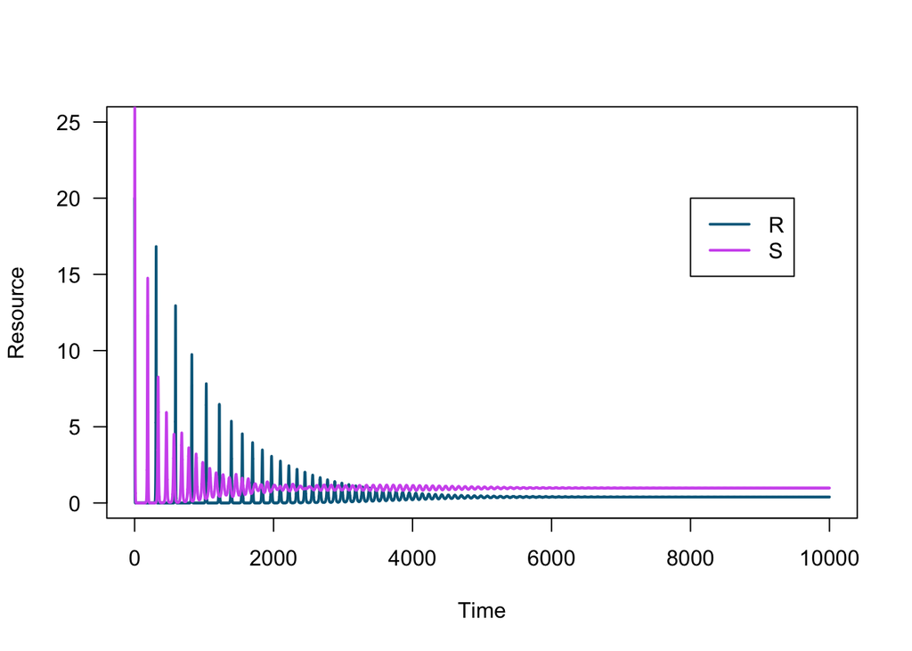

```r
# plot resource as a function of time
plot(x = tset5, y = R.simu5,
     type = 'l', las = 1, lwd = 2, col = Rcol,
     xlab = 'Time', ylab = 'Resource',
     ylim = c(0, K/4))
lines(x = tset5,y = S.simu5,
      lwd = 2, col = Scol)
legend(x = 8000, y = K/5, legend = c('R', 'S'), lwd = 2, col = c(Rcol, Scol))
```

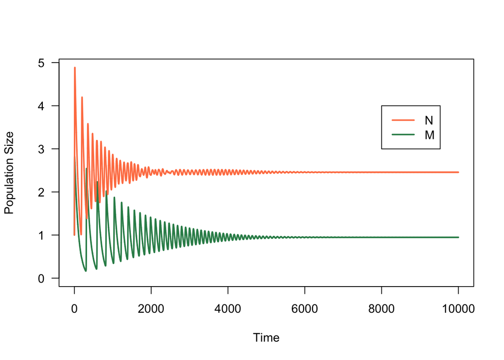

```r
# store a color for M
Mcol <- 'seagreen'

# plot M and N as a function of time
plot(x = tset5, y = M.simu5,
     type = 'l', las = 1, lwd = 2, col = Mcol,
     ylab ='Population Size', xlab = 'Time',
     ylim = c(0, max(c(max(M.simu5, N.simu5)))))
lines(x = tset5, y = N.simu5,
      lwd = 2, col = Ncol)
legend(x = 8000, y = 4,
       legend = c('N', 'M'),
       lwd = 2, col = c(Ncol, Mcol))
```

### Think, Pair, Share 3

1. Use the `tail()` function to compare the equilibrium resource levels to the $R^*$ and $S^*$ values for each competitor.

```r
#rabbitfish equi level
tail(R.simu5) #equi
```

```
## [1] 0.3920879 0.3920889 0.3920900 0.3920910 0.3920920 0.3920931
```

```r
#shrimp equi level
tail(S.simu5) #equi
```

```
## [1] 0.9805237 0.9805229 0.9805221 0.9805213 0.9805205 0.9805198
```

```r
#shrimp time
Sstar_M
```

```
## [1] 50
```

```r
Sstar_N #matches equi value of shrimp, thus nursesharks are driving the shrimp
```

```
## [1] 1
```

```r
#rabbitfish time
Rstar_M
```

```
## [1] 0.4
```

```r
Rstar_N
```

```
## [1] 20
```

2. How would you interpret these results biologically? Consumer N prefers and is therefore limited by resource S and has a lower S*. Nursesharks deplete shrimp to its S* of 1 and competitively exclude morays on shrimp (morays can’t survive on the shrimp).

Morays aprefer and are limited by rabbitfish and have a lower R* for the rabbitfish. Morays deplete rabbitfish to the R* of 0.4 and comeptitvely exclude nursesharks on rabbitfish.

3. Run an additional simulation in which only species M is present. (You can do this in two ways: by using code from Part 2B and replacing species N with species M, or by using code from Part 2E and setting the initial population size of N to 0.)

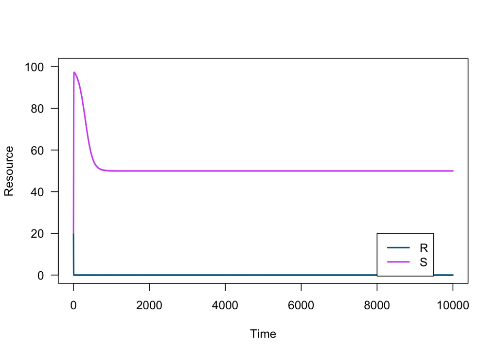

```r
# creating holding vectors and filling initial conditions
R.simu6 <- NaN*tset5; R.simu6[1] <- 20
S.simu6 <- NaN*tset5; S.simu6[1] <- 20
N.simu6 <- NaN*tset5; N.simu6[1] <- 0 #no nursesharks to start
M.simu6 <- NaN*tset5; M.simu6[1] <- 1

# for each timestep
for(i in 2:length(tset5)){
  # calculate change in time
    dt <- tset5[i]-tset5[i-1]

    # store placeholder variables
    R <- R.simu6[i-1]
    S <- S.simu6[i-1]
    N <- N.simu6[i-1]
    M <- M.simu6[i-1]

    # calculate change in resource level and population size
    dR <- ( r*R*(1-R/K) - a_N*N*R - a_M*M*R )*dt
    dS <- ( r*S*(1-S/K) - b_N*N*S - b_M*M*S )*dt
    dN <- ( e*N*(a_N*R+b_N*S) - l_N*N )*dt
    dM <- ( e*M*(a_M*R+b_M*S) - l_M*M )*dt

    # calculate total resource level and population size
    R.simu6[i] <- R + dR
    S.simu6[i] <- S + dS
    N.simu6[i] <- N + dN
    M.simu6[i] <- M + dM
}
# plot resource as a function of time
plot(x = tset5, y = R.simu6,
     type = 'l', las = 1, lwd = 2, col = Rcol,
     xlab = 'Time', ylab = 'Resource',
     ylim = c(0, 100))
lines(x = tset5,y = S.simu6,
      lwd = 2, col = Scol)
legend(x = 8000, y = K/5, legend = c('R', 'S'), lwd = 2, col = c(Rcol, Scol))
```

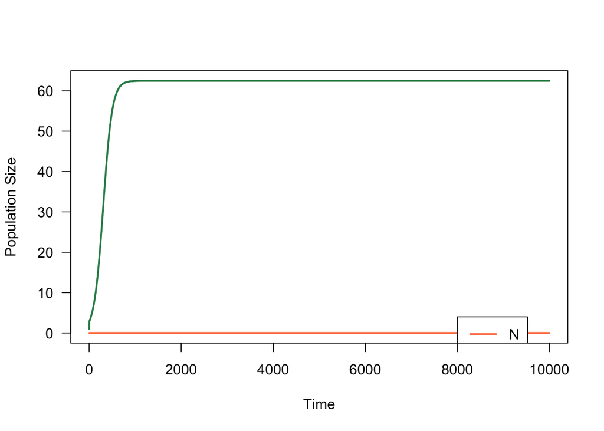

```r
# store a color for M
Mcol <- 'seagreen'


# plot M and N as a function of time
plot(x = tset5, y = M.simu6,
     type = 'l', las = 1, lwd = 2, col = Mcol,
     ylab ='Population Size', xlab = 'Time',
     ylim = c(0, max(c(max(M.simu6, N.simu6)))))
lines(x = tset5, y = N.simu6,
      lwd = 2, col = Ncol)
legend(x = 8000, y = 4,
       legend = c('N', 'M'),
       lwd = 2, col = c(Ncol, Mcol))
```

4. Compare your N-only, M-only, and two-competitor simulations by plotting:

Note to self N_only- simu3 red M_only- simu 6 orange Both- simu 5 yellow

1. resource R as a function of time for the N only, M only, and N and M scenarios:

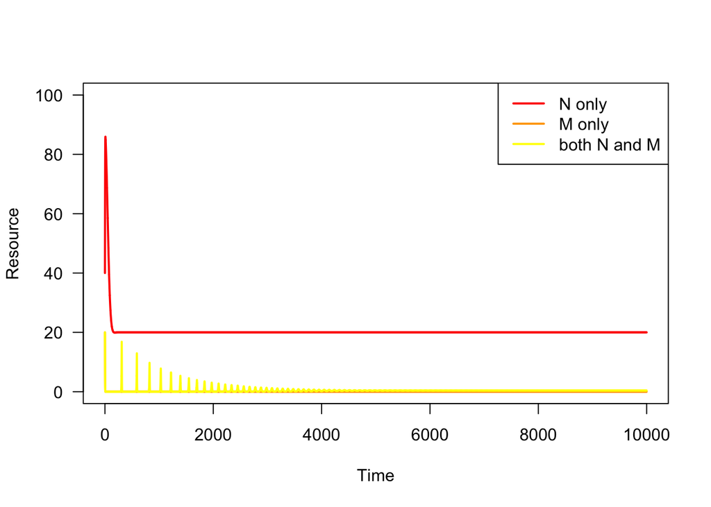

```r
# plot resource as a function of time
plot(x = tset3, y = R.simu3, #nurse shark only
     type = 'l', las = 1, lwd = 2, col = 'red',
     xlab = 'Time', ylab = 'Resource',
     ylim = c(0, 100))
lines(x = tset5,y = R.simu6,#moray only
      lwd = 2, col = 'orange')
lines(x = tset5,y = R.simu5,#both
      lwd = 2, col = 'yellow')
legend(x = 'topright', legend = c('N only', 'M only', 'both N and M'), lwd = 2, col = c('red', 'orange', 'yellow'))
```

2. resource S as a function of time for the N only, M only, and N and M scenarios:

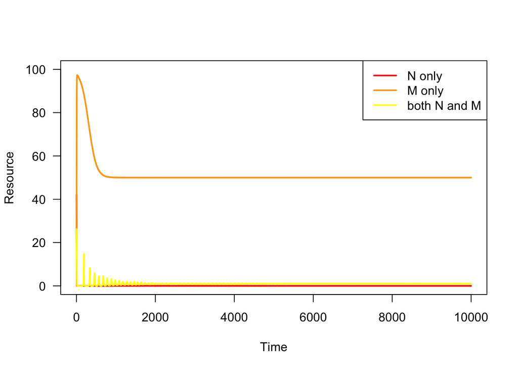

```r
# plot S as a function of time
plot(x = tset3, y = S.simu3, #nurse shark only
     type = 'l', las = 1, lwd = 2, col = 'red',
     xlab = 'Time', ylab = 'Resource',
     ylim = c(0, 100))
lines(x = tset5,y = S.simu6,#moray only
      lwd = 2, col = 'orange')
lines(x = tset5,y = S.simu5,#both
      lwd = 2, col = 'yellow')
legend(x = 'topright', legend = c('N only', 'M only', 'both N and M'), lwd = 2, col = c('red', 'orange', 'yellow'))
```

3. population sizes as a function of time for the N only, M only, and N and M scenarios:

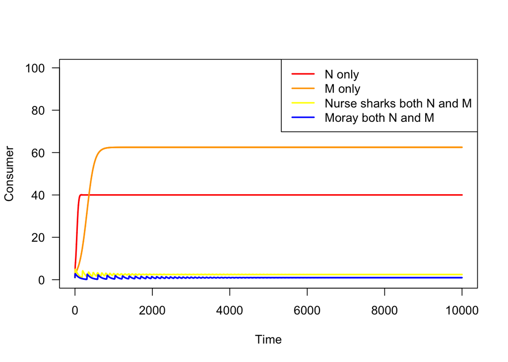

```r
# plot N as a function of time
plot(x = tset3, y = N.simu3, #nurse shark only
     type = 'l', las = 1, lwd = 2, col = 'red',
     xlab = 'Time', ylab = 'Consumer',
     ylim = c(0, 100))
lines(x = tset5,y = M.simu6,#moray only
      lwd = 2, col = 'orange')
lines(x = tset5,y = N.simu5,#both
      lwd = 2, col = 'yellow')
lines(x = tset5,y = M.simu5,#both
      lwd = 2, col = 'blue')
legend(x = 'topright', legend = c('N only', 'M only', 'Nurse sharks both N and M', 'Moray both N and M'), lwd = 2, col = c('red', 'orange', 'yellow', 'blue'))
```

For which do you observe the highest equilibrium population sizes of each competitor? The highest resource levels? Describe your results.

# 3. Predator-mediated coexistence

## a. Modeling a ‘top predator’

Coexistence may also be mediated by top-down mechanisms, such as when the competitors share a common predator.

We can write ODEs that describe such a system. We’ll use the variable `P` to represent the predator, who has attack rates `g_N` and `g_M` on species N and M, respectively. The predator will have its own conversion efficiency, `c`, and its own mortality, `d_P`. The system of ODEs is as follows:

$$\begin{align}
Resource R:
\frac{d R}{dt} &= r R (1-\frac{R}{K}) - a_N R N - a_M R M \\
\newline
Prey N:
\frac{d N}{dt} &= e a_N R N - l_N N - g_N N P \\
\newline
Prey M:
\frac{d M}{dt} &= e a_M R M - l_M M - g_M M P \\
\newline
Predator:
\frac{d P}{dt} &= c P (g_N N+g_M M) - d_P P \\
\end{align}$$

Resource Parameters

```r
r <- .5     # Intrinsic growth rate of the resource
K <- 100    # Carrying capacity of the resource
```

Competitor Parameters

```r
a_N <- 0.2  # Affinity or attack rate of N for/on the resource R
a_M <- a_N*1.5  # Affinity or attack rate of M for/on resource R
e <- 0.05   # Conversion efficiency of R into N and M
l_N <- 0.01 # Mortality rate of N
l_M <- l_N  # Mortality rate of M
```

Recall: In our simulation in Part 1, M was the dominant competitor.

```r
Rstar_N <- l_N/e/a_N
Rstar_N
```

```
## [1] 1
```

```r
Rstar_M <- l_M/e/a_M
Rstar_M
```

```
## [1] 0.6666667
```

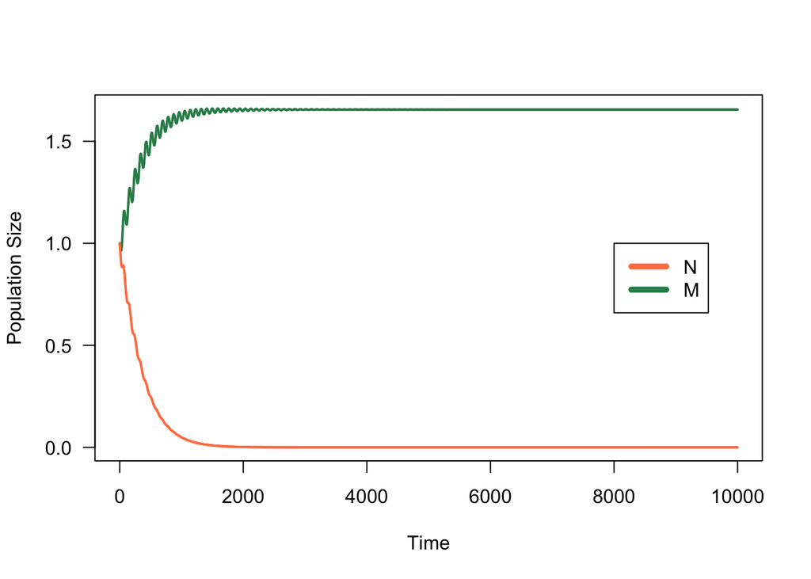

```r
plot(x = tset1, y = M.simu1,
     type = 'l', las = 1, lwd = 2, col = Mcol,
     xlab = 'Time', ylab='Population Size',
     ylim = c(0, max(c(max(M.simu1,N.simu1)))))
lines(x = tset1, y = N.simu1,
      lwd = 2, col = Ncol)
legend(x = 8000, y = 1, legend = c('N', 'M'), lwd = 5, col = c(Ncol, Mcol))
```

### Think, Pair, Share 4

we’ll see more rabitfish with the addition of the person predator

## b. Simulating predation

Let’s choose our parameters for our predators.

```r
c <- 0.05       # Predator's conversion efficiency
d_P <- 0.001    # Predator's mortality
g_N <- 0.005    # Predation rate on competitor N
g_M <- 0.015    # Predation rate on competitor M
```

### Think, Pair, Share 5

1. Copy the following code (which comes from Part 1C, above) and paste it into the next code chunk. Modify the code to allow for predation. HINT: Remember to modify dN and dM, as well as putting in a new equation for dP.

```r
tset7 <- seq(from = 0, to = 10000, length.out = 100020)

# create holding vectors and fill initial conditions
R.simu7 <- NaN*tset7; R.simu7[1] <- 0.5
N.simu7 <- NaN*tset7; N.simu7[1] <- 1
M.simu7 <- NaN*tset7; M.simu7[1] <- 1

# for each timestep
for(i in 2:length(tset7)){
  # calculate change in time
    dt <- tset7[i]-tset7[i-1]

    # store placeholder variables
    R <- R.simu7[i-1]
    N <- N.simu7[i-1]
    M <- M.simu7[i-1]

    # calculate change in resource level and population size
    dR <- ( r*R*(1-R/K) - a_N*N*R - a_M*M*R )*dt
    dN <- ( e*a_N*N*R - l_N*N )*dt
    dM <- ( e*a_M*M*R - l_M*M )*dt

    # calculate total resource level and population size
    R.simu7[i] <- R + dR
    N.simu7[i] <- N + dN
    M.simu7[i] <- M + dM
}
```

```r
#EDIT THIS ONE
#modify dn and dM as well as equation for dP
tset7 <- seq(from = 0, to = 10000, length.out = 100020)

# create holding vectors and fill initial conditions
R.simu7 <- NaN*tset7; R.simu7[1] <- 0.5
N.simu7 <- NaN*tset7; N.simu7[1] <- 1
M.simu7 <- NaN*tset7; M.simu7[1] <- 1
P.simu7 <- NaN*tset7; P.simu7[1] <- 1 #add

# for each timestep
for(i in 2:length(tset7)){
  # calculate change in time
    dt <- tset7[i]-tset7[i-1]

    # store placeholder variables
    R <- R.simu7[i-1]
    N <- N.simu7[i-1]
    M <- M.simu7[i-1]
    P <- P.simu7[i-1] #add

    # calculate change in resource level and population size
    dR <- ( r*R*(1-R/K) - a_N*N*R - a_M*M*R )*dt #no change necessary
    dN <- ( e*a_N*N*R - l_N*N -g_N*N*P )*dt #add in predation on nurse sharks
    dM <- ( e*a_M*M*R - l_M*M -g_M*M*P)*dt #add
    dP <- (c*P*(g_N*N+ g_M*M)-d_P*P)*dt

    # calculate total resource level and population size
    R.simu7[i] <- R + dR
    N.simu7[i] <- N + dN
    M.simu7[i] <- M + dM
    P.simu7[i] <- P + dP #add p here
}
```

Check to make sure you’re at equilibrium using the `tail()` function:

```r
#nurse shark equi level
tail(N.simu7) #equi
```

```
## [1] 1.215738 1.215853 1.215968 1.216083 1.216198 1.216313
```

```r
#moray eel equi level
tail(M.simu7) #equi
```

```
## [1] 0.8300440 0.8299676 0.8298912 0.8298148 0.8297384 0.8296620
```

2. Modify the following code to plot your results. HINT: You’ll need to make a third plot to show the predator’s dynamics

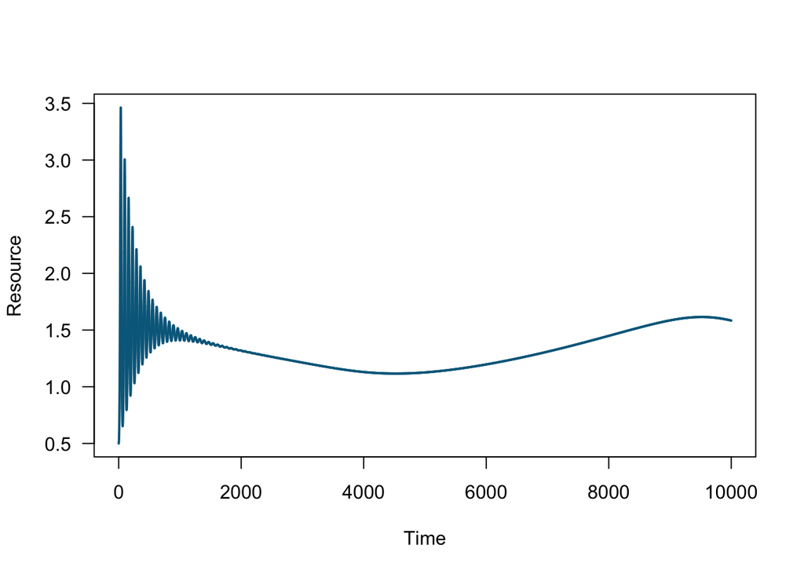

```r
Rcol <- 'deepskyblue4'
Ncol <- 'coral'
Mcol <- 'seagreen'
Pcol <- 'grey22'

# plot R in new simulation
plot(x = tset7, y = R.simu7,
     type = "l", las = 1, lwd = 2, col = Rcol,
     xlab = "Time", ylab = "Resource")
```

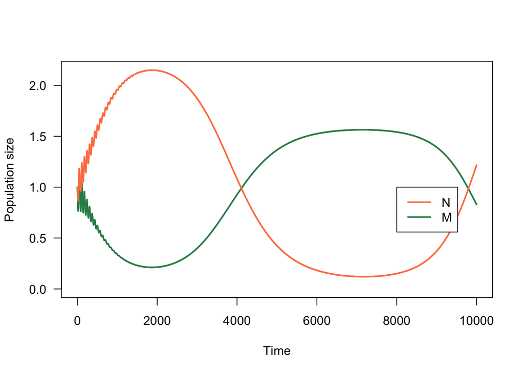

```r
# plot M in new simulation
plot(x = tset7, y = M.simu7,
     type = "l", las = 1, lwd = 2, col = Mcol,
     xlab = "Time", ylab = "Population size",
     ylim = c(0, max(c(max(M.simu7, N.simu7)))))
# plot N in new simulation
lines(x = tset7, y = N.simu7, lwd = 2, col = Ncol)
legend(x = 8000, y = 1,
       legend = c("N", "M"),
       lwd = 2, col = c(Ncol, Mcol))
```

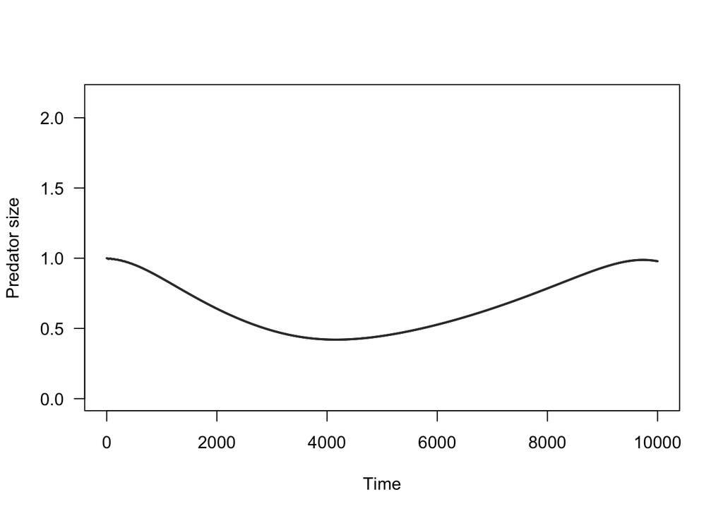

```r
# plot P in new simulation
plot(x = tset7, y = P.simu7,
     type = "l", las = 1, lwd = 2, col = Pcol,
     xlab = "Time", ylab = "Predator size",
     ylim = c(0, max(c(max(M.simu7, N.simu7)))))
```

3. Will coexistence occur? (HINT: Look at your plots, because you are probably observing some cycling.)
4. Were your predictions (about coexistence and changes to resource availability) correct? Why or why not?

# 4. Homework

Set up any variables you need here.

# HW 1

## 1. Altering parameters

Using the model from Part One (two competitors, one resource), alter the parameters such that a_N > a_M, and l_N > l_M. List your parameters here. **Print the values of a_N, a_M, l_N, and l_M.** Is a_N greater than a_M, and is l_N greater than l_M? Double check by running `a_N > a_M` and `l_N > l_M` and making sure both of those yield the output `TRUE`.

```r
a_Mhw <- 0.2 # attack rate of morays
l_Mhw <- 0.01      # but death rate is the same

a_Nhw <- 2*a_Mhw    # attack rate of our nurse sharks is bigger than that of morays
ehw <- 0.05   # conversion efficiency
l_Nhw <- 4*l_Mhw    # death rate of nurse sharks
```

```r
# output the parameter values here a_N, a_M, l_N, and l_M
# make sure they print in your knitted version!
a_Nhw
```

```
## [1] 0.4
```

```r
l_Nhw
```

```
## [1] 0.04
```

```r
a_Mhw
```

```
## [1] 0.2
```

```r
l_Mhw
```

```
## [1] 0.01
```

```r
# Double check by running `a_N > a_M` and `l_N > l_M` and making sure both of those yield the output `TRUE`
a_Nhw > a_Mhw
```

```
## [1] TRUE
```

```r
l_Nhw > l_Mhw
```

```
## [1] TRUE
```

**Answer in words here, be concise: Is a_N greater than a_M, and is l_N greater than l_M?** Yes, a_N is greater than a_M and l_N is greater than l_M.

= /2 points total

# HW 2

## 2. Calculating R*

Calculate R* for both species N and species M.

```r
#calculate R*
Rstar_Nhw <- l_Nhw/ehw/a_Nhw
Rstar_Nhw
```

```
## [1] 2
```

```r
Rstar_Mhw <- l_Mhw/ehw/a_Mhw
Rstar_Mhw
```

```
## [1] 1
```

**Answer in words here**: R* for N is: 2

**Answer in words here**: R* for M is: 1

= /2 points total

# HW 3

## 3. Making a prediction

Based on your calculation, predict which species should “win” competition.

**Answer in words here, be concise**: Since species M has a lower R* than species N, then I anticipate species M being competitve dominant and the “winner”. While I doubled N’s attack rate, I also quadruppled its death rate. This led to its R* being higher than M’s.

= /1 point total

# HW 4

## 4. Running a simulation

Run a simulation and show timeseries plot(s) to confirm your prediction.

/2 points for two sets of axes  
/3 points for each line (R, N, M)  
/1 point for legend  
/2 points for code  
= /8 points total

```r
# create holding vectors and fill initial conditions
R.simuhw <- NaN*tset1; R.simuhw[1] <- 0.5
N.simuhw <- NaN*tset1; N.simuhw[1] <- 1
M.simuhw <- NaN*tset1; M.simuhw[1] <- 1

# for each timestep
for(i in 2:length(tset1)){
  # calculate change in time
    dt <- tset1[i]-tset1[i-1]

    # store placeholder variables
    R <- R.simuhw[i-1]
    N <- N.simuhw[i-1]
    M <- M.simuhw[i-1]

    # calculate change in resource level and population size
    dR <- ( r*R*(1-R/K) - a_Nhw*N*R - a_Mhw*M*R )*dt
    dN <- ( ehw*a_Nhw*N*R - l_Nhw*N )*dt
    dM <- ( ehw*a_Mhw*M*R - l_Mhw*M )*dt

    # calculate total resource level and population size
    R.simuhw[i] <- R + dR
    N.simuhw[i] <- N + dN
    M.simuhw[i] <- M + dM
}

head(N.simuhw)
```

```
## [1] 1.0000000 0.9970000 0.9939987 0.9909966 0.9879938 0.9849906
```

```r
tail(N.simuhw)
```

```
## [1] 7.011208e-87 6.997185e-87 6.983191e-87 6.969224e-87 6.955286e-87
## [6] 6.941375e-87
```

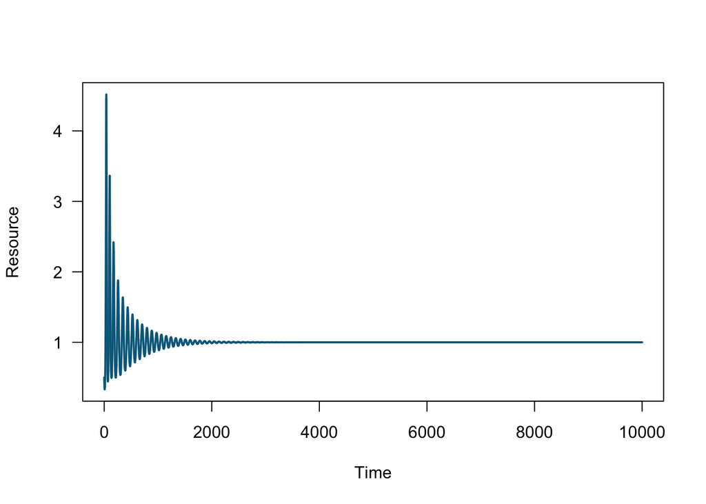

```r
################################
#Plot
# store colors for R, N, and M - feel free to use your own!
Rcol <- 'deepskyblue4'
Ncol <- 'coral'
Mcol <- 'seagreen'

# plot resource as a function of time
plot(x = tset1, y = R.simuhw,
     type = 'l', las = 1, lwd = 2, col = Rcol,
     xlab = 'Time', ylab = 'Resource')
```

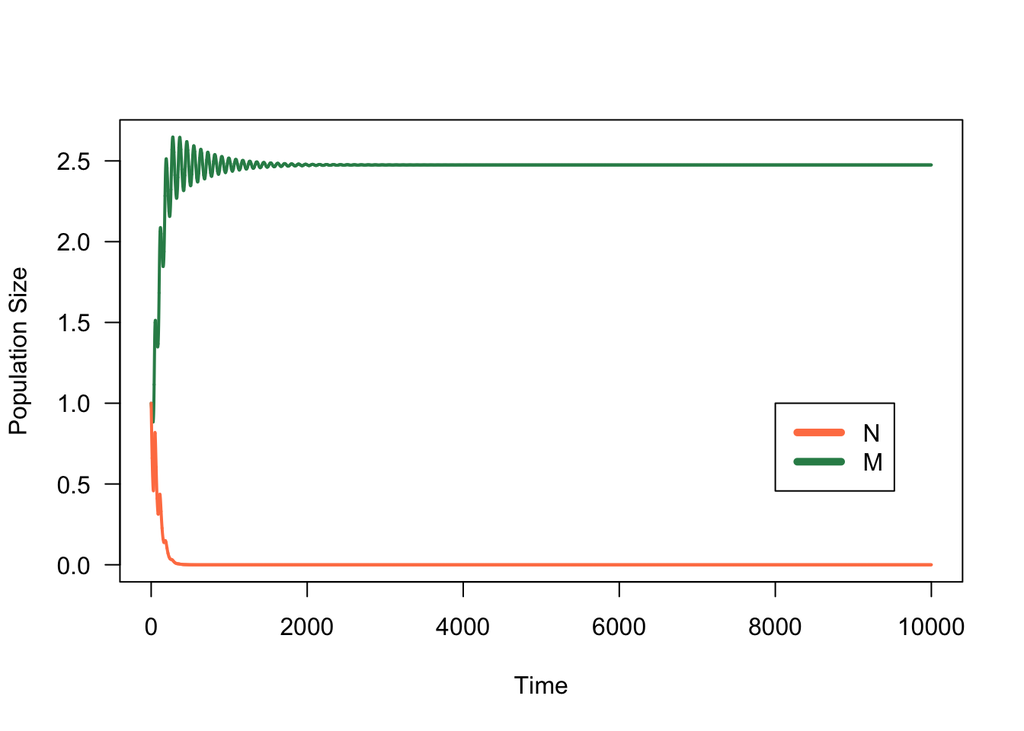

```r
# plot population size of M and N as a function of time
plot(x = tset1, y = M.simuhw,
     type = 'l', las = 1, lwd = 2, col = Mcol,
     xlab = 'Time', ylab = 'Population Size',
     ylim = c(0, max(c(max(M.simuhw,N.simuhw)))))
lines(x = tset1, y = N.simuhw,
      lwd = 2, col = Ncol)
legend(x = 8000, y = 1, legend = c('N', 'M'), lwd = 5, col = c(Ncol, Mcol))
```

# HW 5

## 5. Altering initial conditions

Try some different initial conditions. (**Hint:** where do you fill in initial conditions before running your simulation?) Do you believe that the system has only one stable equilibrium (i.e. do R, N, and M equilibrate to the same values regardless of starting conditions)?

I do believe that the system has only one stable equiloibrium. I tried multiple different R, N, and M initial conditions and they all ended up at the same equilibria. Even though they looked slightly different getting to that equilibria, they reached the same equilibria eventually.

/2 points for a simulation with different initial conditions  
/2 points for either a plot or tail values to find stable equilibria  
/1 point for answer  
/2 points for code  
= /7 points total

```r
# create holding vectors and fill initial conditions
R.simuhw2 <- NaN*tset1; R.simuhw2[1] <- 0.5
N.simuhw2 <- NaN*tset1; N.simuhw2[1] <- 5
M.simuhw2 <- NaN*tset1; M.simuhw2[1] <- 1

# for each timestep
for(i in 2:length(tset1)){
  # calculate change in time
    dt <- tset1[i]-tset1[i-1]

    # store placeholder variables
    R <- R.simuhw2[i-1]
    N <- N.simuhw2[i-1]
    M <- M.simuhw2[i-1]

    # calculate change in resource level and population size
    dR <- ( r*R*(1-R/K) - a_Nhw*N*R - a_Mhw*M*R )*dt
    dN <- ( ehw*a_Nhw*N*R - l_Nhw*N )*dt
    dM <- ( ehw*a_Mhw*M*R - l_Mhw*M )*dt

    # calculate total resource level and population size
    R.simuhw2[i] <- R + dR
    N.simuhw2[i] <- N + dN
    M.simuhw2[i] <- M + dM
}

head(N.simuhw)
```

```
## [1] 1.0000000 0.9970000 0.9939987 0.9909966 0.9879938 0.9849906
```

```r
tail(N.simuhw)
```

```
## [1] 7.011208e-87 6.997185e-87 6.983191e-87 6.969224e-87 6.955286e-87
## [6] 6.941375e-87
```

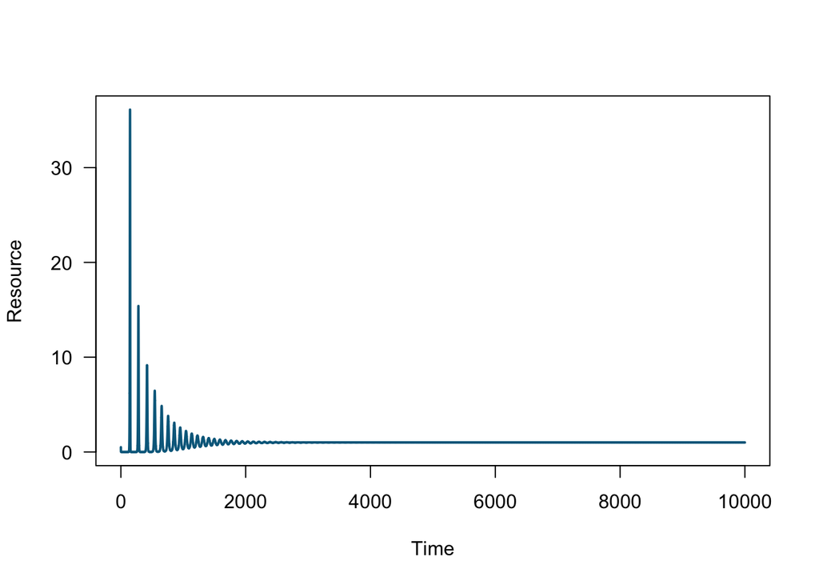

```r
################################
#Plot

# plot resource as a function of time
plot(x = tset1, y = R.simuhw2,
     type = 'l', las = 1, lwd = 2, col = Rcol,
     xlab = 'Time', ylab = 'Resource')
```

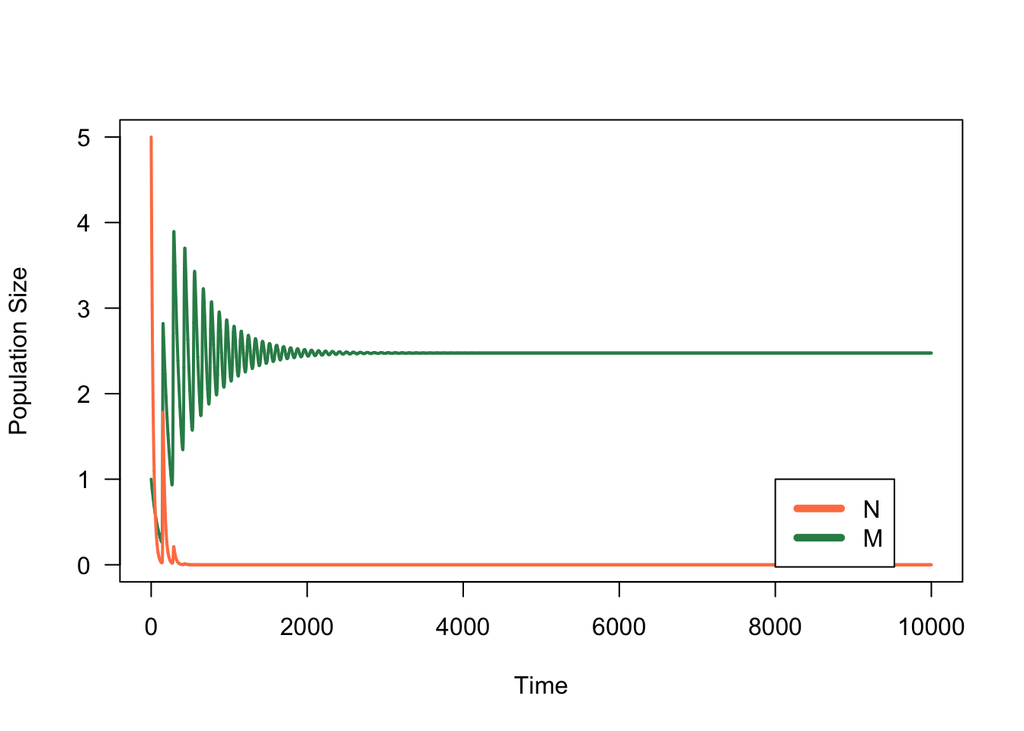

```r
# plot population size of M and N as a function of time
plot(x = tset1, y = M.simuhw2,
     type = 'l', las = 1, lwd = 2, col = Mcol,
     xlab = 'Time', ylab = 'Population Size',
     ylim = c(0, max(c(max(M.simuhw2,N.simuhw2)))))
lines(x = tset1, y = N.simuhw2,
      lwd = 2, col = Ncol)
legend(x = 8000, y = 1, legend = c('N', 'M'), lwd = 5, col = c(Ncol, Mcol))
```

# HW 6

## 6. Bifurcation diagrams

Make three bifurcation diagrams showing the stable equilibria for R, N, and M as a function of K (the carrying capacity of the shared resource).

**Hint:** bifurcation diagrams not showing up the way you think they should? Try using a smaller range of values for `Kset`. It would be easier to see the dynamics of the system if you run your `Kset` vector to 20.

/3 points for two or three sets of axes  
/3 points for each line (R, N, M)  
/3 points for code  
= /9 points

```r
Kset <- seq(from = 0, to = 20,length.out = 50) #densities I want to look at

Rstarset <- NaN*Kset
Nstarset <- NaN*Kset
Mstarset <- NaN*Kset

for(j in 1:length(Kset)){
  # assign the value of Y
    K.new <- Kset[j]

    # create a holding vector for predator and prey populations
    # and fill with initial conditions
    R.simuhw6 <- NaN*tset1
    R.simuhw6[1] <- 1
    N.simuhw6 <- NaN*tset1
    N.simuhw6[1] <- 1
    M.simuhw6 <- NaN*tset1
    M.simuhw6[1] <- 1
    P.simu6 <- NaN*tset1

    for(i in 2:length(tset1)){
      # calculating change in time
        dt <- tset1[i]-tset1[i-1]

        # storing temporary variables
        R <- R.simuhw6[i-1]
        N <- N.simuhw6[i-1]
        M <- M.simuhw6[i-1]

            # calculate change in resource level and population size
    dR <- ( r*R*(1-R/K.new) - a_Nhw*N*R - a_Mhw*M*R )*dt
    dN <- ( ehw*a_Nhw*N*R - l_Nhw*N )*dt
    dM <- ( ehw*a_Mhw*M*R - l_Mhw*M )*dt

    # calculate total resource level and population size
    R.simuhw6[i] <- R + dR
    N.simuhw6[i] <- N + dN
    M.simuhw6[i] <- M + dM
    }

    # storing last population size (equilibrium population size) in holding vector
    Rstarset[j] <- R.simuhw6[length(tset1)]
    Nstarset[j] <- N.simuhw6[length(tset1)]
    Mstarset[j] <- M.simuhw6[length(tset1)]

}

head(Rstarset)
```

```
## [1]       NaN 0.4081633 0.8163265 1.0000000 1.0000000 1.0000000
```

```r
head(Nstarset)
```

```
## [1]           NaN 1.746452e-139 1.272890e-104  2.371462e-88  1.062698e-87
## [6]  1.842784e-87
```

```r
head(Mstarset)
```

```
## [1]          NaN 1.424178e-26 3.492702e-09 4.583333e-01 9.687500e-01
## [6] 1.275000e+00
```

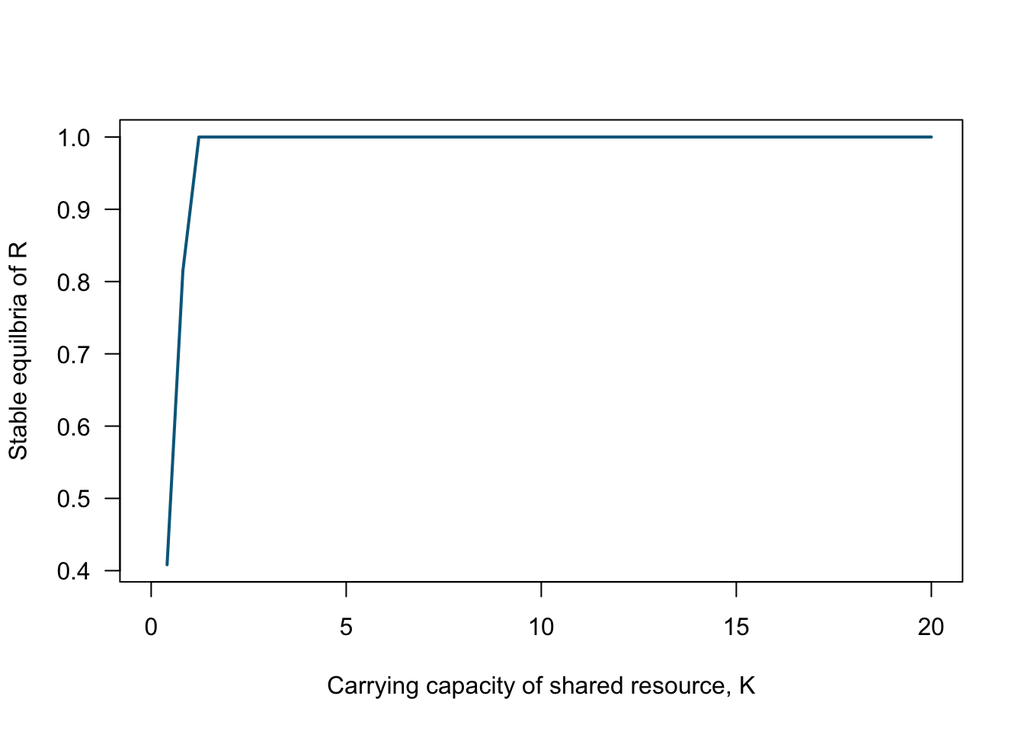

```r
#########################
#R plot
# plot stable equilibria of R against K
plot(x = Kset, y = Rstarset,
     type = 'l', lwd = 2, col = Rcol, las = 1,
     xlab = 'Carrying capacity of shared resource, K', ylab = 'Stable equilbria of R')
```

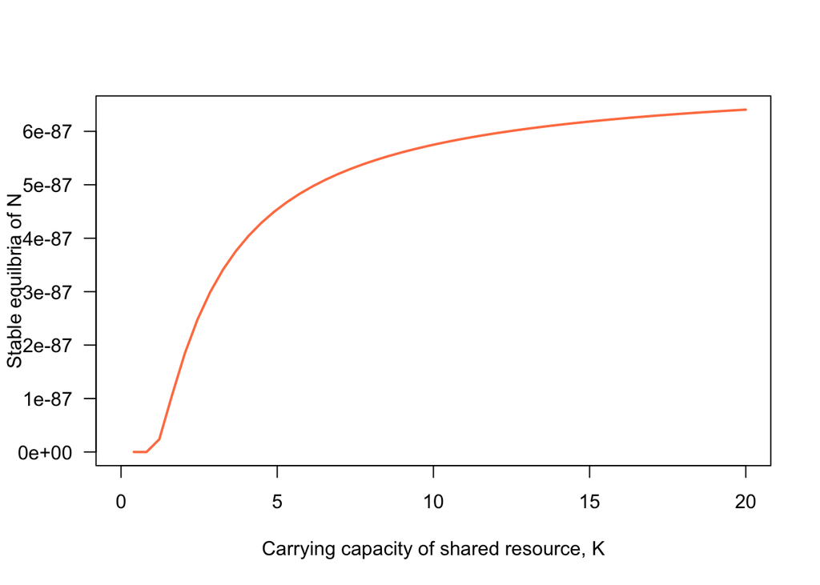

```r
#N plot
# plot stable equilibria of N against K
plot(x = Kset, y = Nstarset,
     type = 'l', lwd = 2, col = Ncol, las = 1,
     xlab = 'Carrying capacity of shared resource, K', ylab = 'Stable equilbria of N')
```

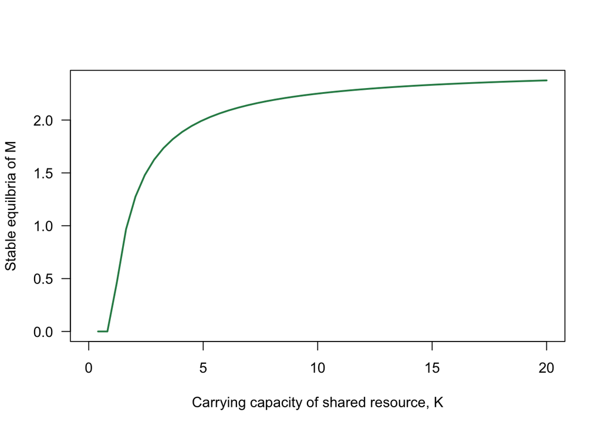

```r
#M plot
# plot stable equilibria of M against K
plot(x = Kset, y = Mstarset,
     type = 'l', lwd = 2, col = Mcol, las = 1,
     xlab = 'Carrying capacity of shared resource, K', ylab = 'Stable equilbria of M')
```

# HW 7

## 7. Interpret results

Describe your bifurcation diagrams from Question 6 in words. What is the ecological interpretation of your findings?

= /4 points total

# HW 8

## 8. Predator-mediated coexistence

If there were a predator in your system, which prey item would it have to prefer in order for the two species to coexist?

**It would have to prefer species M (moray eel)**

= /1 point total